# Data Analysis: the Relationship between Alcohol Consumption and Life Expectancy

Jack Tan, Krista Zhang, Yiming Miao

2020/10/14

## Introduction

In this project, we are trying to investigate whether alcohol consumption would significantly affect life expectancy. We collected data across countries, like the alcohol consumption per capita, average life expectancy at birth, average literacy rate and national income. By joining these data and conducting regression / inverse-probability weighting analysis, we hope to successfully investigate the true relationship between alcohol consumption and life expectancy.

## Preparations

### Loading Packages

```r
library(readxl)
library(readr)
library(tidyverse)
library(ggmap)
```

```r
library(ggthemes)
library(maps)
library(openintro)
library(tmaptools)
library(httr)
library(lubridate)
library(caret)
library(VIM)
library(pcalg)
library(splines)
library(survey)
set.seed(451)
```

### Loading Dataset

```r
alcohol_consumption <- read.csv("../dataset/alcohol_consumption.csv")
literacy <- read.csv("../dataset/cross-country-literacy-rates.csv")
income <- read_excel("../dataset/national_income.xlsx")
life_exp <- read.csv("../dataset/life_expectancy.csv")
happiness <- read.csv("../dataset/happiness-cantril-ladder.csv")
health_expenditure <- read_excel("../dataset/expenditure.xlsx")
```

Literacy and happiness were both achieved from the website called Our World in Data. Literacy rates was data combined from World Bank, CIA World Factbook and other sources. Happiness was collected from World Happiness Report 2019, meausred in Cantril Ladder.

The geographical location data was obtained through google map api using the country names listed in the `alcohol_consumption` dataset and incorporated into the same one.

The rest variables, life expectancy, alcohol consumption and the percentage of government expenditure on health are from World Health Organization.

### Readying Dataset

```r
life_exp_2015 <- life_exp %>%
  filter(Year == "2015")
```

```r
income_2015 <- income %>%
  select(income_2015, Country)
```

```r
happiness_2015 <- happiness %>%
  filter(Year == "2015")
```

```r
literacy_2015 <- literacy %>%
  filter(Year == "2015")
```

### Congregating Dataset

```r
full <- alcohol_consumption %>%
  left_join(life_exp_2015, by = "Country")
full <- full %>%
  left_join(happiness_2015, by = c("Country" = "Entity"))
full <- full %>%
  left_join(income_2015, by = "Country")
full <- full %>%
  left_join(literacy_2015, by = c("Country" = "Entity"))
full <- full %>%
  left_join(health_expenditure, by = "Country")
full <- full %>%
  select(-X, -Year.x, -Code.x, -Year.y, -Code.y, -Year, -health_exp_2016, -Life_expectancy_at_birth_male, -Life_expectancy_at_birth_female, -Life_expectancy_at_age_60_male, -Life_expectancy_at_age_60_female, -Life_expectancy_at_age_60_avg)
```

```r
full <- full %>%
  rename(
    Alcohol_consumption = Both_sexes,
    National_income = income_2015 ,
    Literacy_rate = Literacy ,
    Govexp_health = health_exp_2015,
    Life_exp = Life_expectancy_at_birth_avg
    )

view(full)
```

Since not all countries have data across all variables, we used KNN imputation method to impute the missing values accross the dataset. We will discuss the limiation of using this method later.

```r
full_knn <- full %>%
  VIM::kNN(imp_var = FALSE)
```

KNN is the abbreviation for K Nearest Neighbors, and the general idea for this imputation method is that if 2 cases have similar $x$ values, they likely have similar $y$ values. For instance, `Happiness` for Comoros is missing, the method will impute this NA by looking at other countries that are similar to Comoros in other variables, i.e. with similar national income or with similar geographical location, and weight the data for those countries to get a reasonable imputation for the NA.

### Dataset Information

[output not shown]

### Dataset general view

```r
head(full_knn)
```

```
##               Country Alcohol_consumption Male Female        lon       lat
## 1         Afghanistan                 0.2  0.4    0.1  67.709953  33.93911
## 2             Albania                 6.7 10.9    2.5  20.168331  41.15333
## 3             Algeria                 0.9  1.6    0.2   1.659626  28.03389
## 4             Andorra                11.0 17.2    5.2   1.521801  42.50628
## 5              Angola                 8.0 12.6    3.6  17.873887 -11.20269
## 6 Antigua and Barbuda                 5.9  9.5    2.7 -61.796428  17.06082
##   Life_exp Happiness National_income Literacy_rate Govexp_health
## 1     63.2  3.982855        504.6033      38.16804           0.5
## 2     76.1  4.606651       3234.6973      97.55390           4.4
## 3     76.2  5.163157       3283.1646      79.60840           4.9
## 4     78.6  6.701571      35813.1011      99.05978           5.0
## 5     62.2  4.661013       2078.3009      71.16416           1.2
## 6     75.0  5.791460       3814.1331      92.46542           2.6
```

## Analysis

### 1. Causal Diagram Construction

Below is the causal graph designed by ourselves based our contextual knowledge.

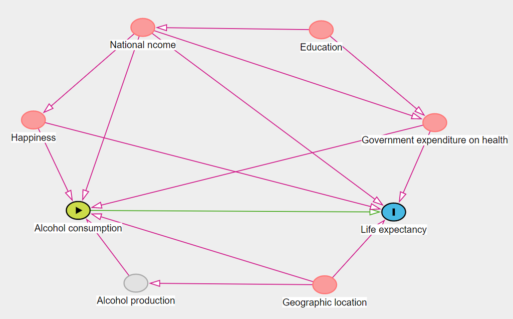

- Non-Causal Paths:
- `Alcohol consumption` <- `Happiness` -> `Life expectancy`
- `Alcohol consumption` <- `Nation income` -> `Life expectancy`
- `Alcohol consumption` <- `Government expenditure on health` -> `Life expectancy`
- `Alcohol consumption` <- `Geographic location` -> `Life expectancy`
- `Alcohol consumption` <- `Happiness` <- `National income` -> `Life expectancy`
- `Alcohol consumption` <- `National income` -> `Government expenditure on health` -> `Life expectancy`
- `Alcohol consumption` <- `Alcohol production` <- `Geographical location` -> `Life expectancy`
- `Alcohol consumption` <- `Happiness` <- `National income` -> `Government expenditure on health` -> `Life expectancy`
- `Alcohol consumption` <- `National income` <- `Education` -> `Government expenditure on health` -> `Life expectancy`
- `Alcohol consumption` <- `Happiness` <- `National income` <- `Education` -> `Government expenditure on health` -> `Life expectancy`

Although there are a total of 10 non-causal paths according to our causal graph, the minimal conditioning set to achieve conditional exchangeability includes only four variables: Z = {`Happiness`, `National income`, `Government expenditure on health`, `Geographical location`}.

### 2. Exploratory Visualization

To better conduct the further analysis, we first visualize the general data distribution:

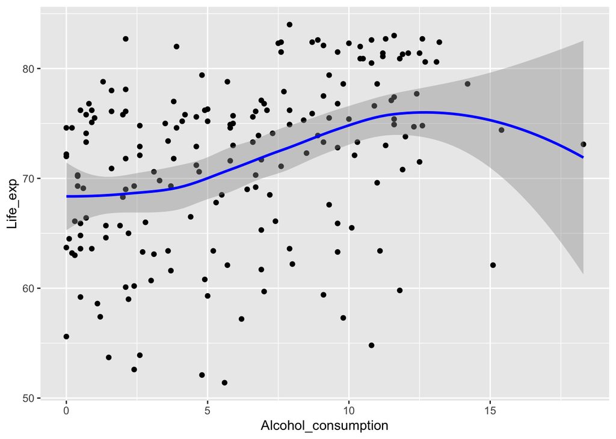

```r
ggplot(full_knn, aes(x= Alcohol_consumption, y=Life_exp))+
  geom_point()+
  geom_smooth(color="blue")
```

From the visualization above, we can find that alchol consumption seems like have a protective effect by extending life expectancy, though the relationship was not that strong. However, this was just the general distribution that might be affected by confounders. In the analyses below, we'd like to add conditioning set in our model, to see the true relation between alcohol consumption and life expectancy.

### 3. Regression Analysis

```r
model_original <- lm(Life_exp ~ Alcohol_consumption, data = full_knn)
summary(model_original)
```

```
##
## Call:
## lm(formula = Life_exp ~ Alcohol_consumption, data = full_knn)
##
## Residuals:
##     Min      1Q  Median      3Q     Max
## -19.937  -3.949   1.566   5.463  13.800
##
## Coefficients:
##                     Estimate Std. Error t value Pr(>|t|)
## (Intercept)          67.4912     0.9150  73.759  < 2e-16 ***
## Alcohol_consumption   0.6709     0.1237   5.424  1.8e-07 ***
## ---
## Signif. codes:  0 '***' 0.001 '**' 0.01 '*' 0.05 '.' 0.1 ' ' 1
##
## Residual standard error: 7.087 on 186 degrees of freedom
## Multiple R-squared:  0.1366, Adjusted R-squared:  0.1319
## F-statistic: 29.42 on 1 and 186 DF,  p-value: 1.798e-07
```

If we conduct a regression model without conditioning on anything, the coefficient for `Alcohol_consumption` was 0.6709, which means that with every extra liter of pure alcohol consumed per year, the life-expectancy is expected to be extended by 0.6709 years on average. The small p-value also indicates its statistical significance. The result is consistent to the graph we ploted above.

However, the comparison should not be fair if we did not condition on any potential confounders. So we conduct a multivariable regression model with the minimum conditioning set we achived above based on our causal diagram, to see the relationship which should be closer to the truth.

To better set the conditioning term, we first visualize the relationship between the confounding variables and $y$(outcome, life expectancy):

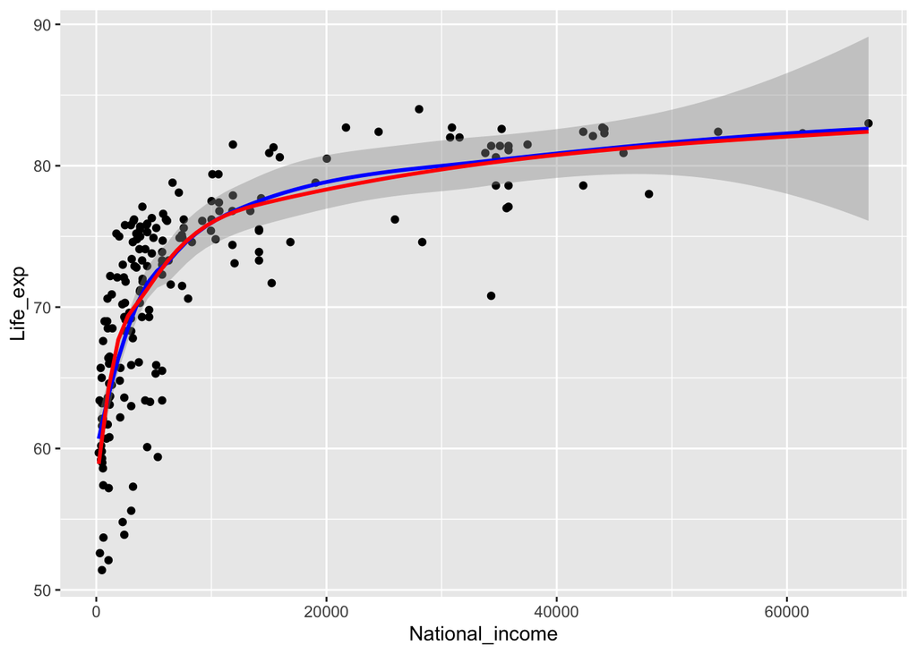

```r
ggplot(full_knn, aes(x=National_income, y=Life_exp))+
  geom_point()+
  geom_smooth(color="blue")+
  geom_smooth(formula = y~ns(x,5),method="lm",
      se= FALSE, color="red"
  )
```

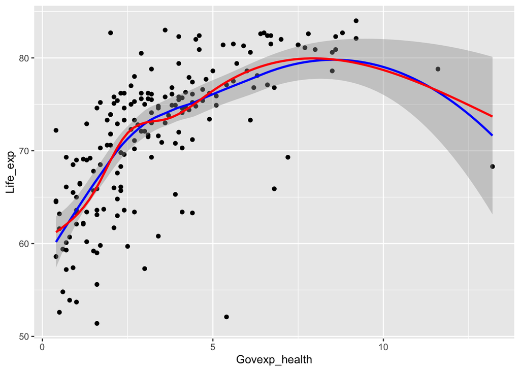

```r
ggplot(full_knn, aes(x=Govexp_health, y=Life_exp))+
  geom_point()+
  geom_smooth(color="blue")+
  geom_smooth(formula = y~ns(x,5),method="lm",
      se= FALSE, color="red"
  )
```

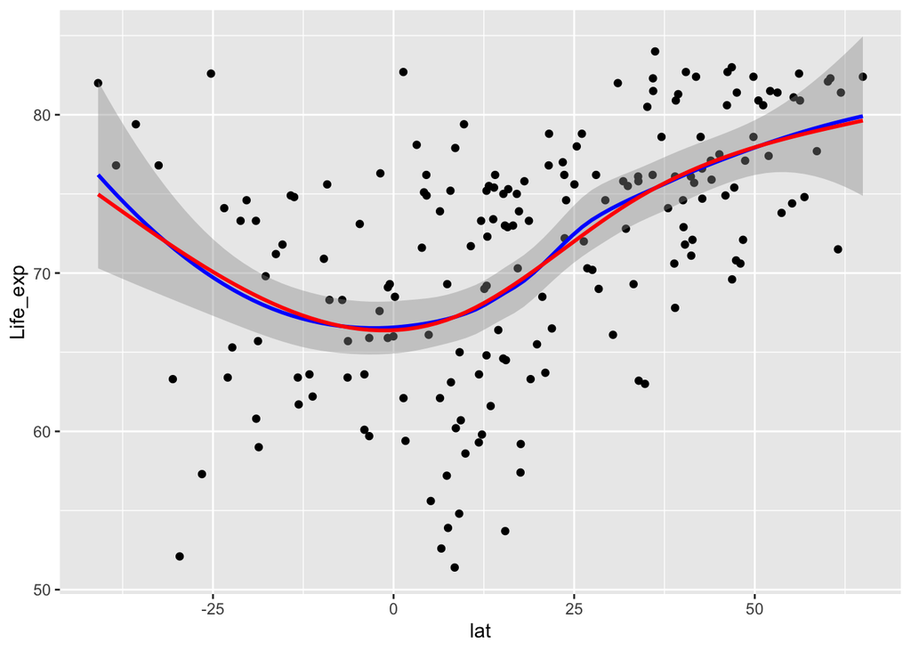

```r
ggplot(full_knn, aes(x=lat, y=Life_exp))+
  geom_point()+
  geom_smooth(color="blue")+
  geom_smooth(formula = y~ns(x,3),method="lm",
      se= FALSE, color="red"
  )
```

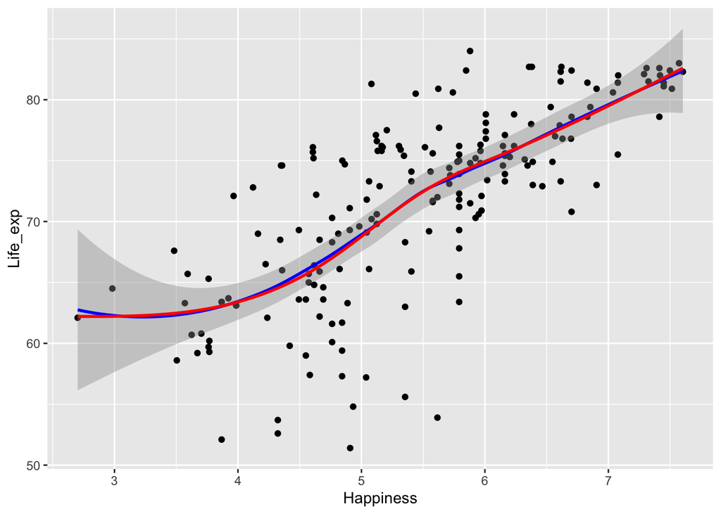

```r
ggplot(full_knn, aes(x=Happiness, y=Life_exp))+
  geom_point()+
  geom_smooth(color="blue")+
  geom_smooth(formula = y~ns(x,4),method="lm",
      se= FALSE, color="red"
  )
```

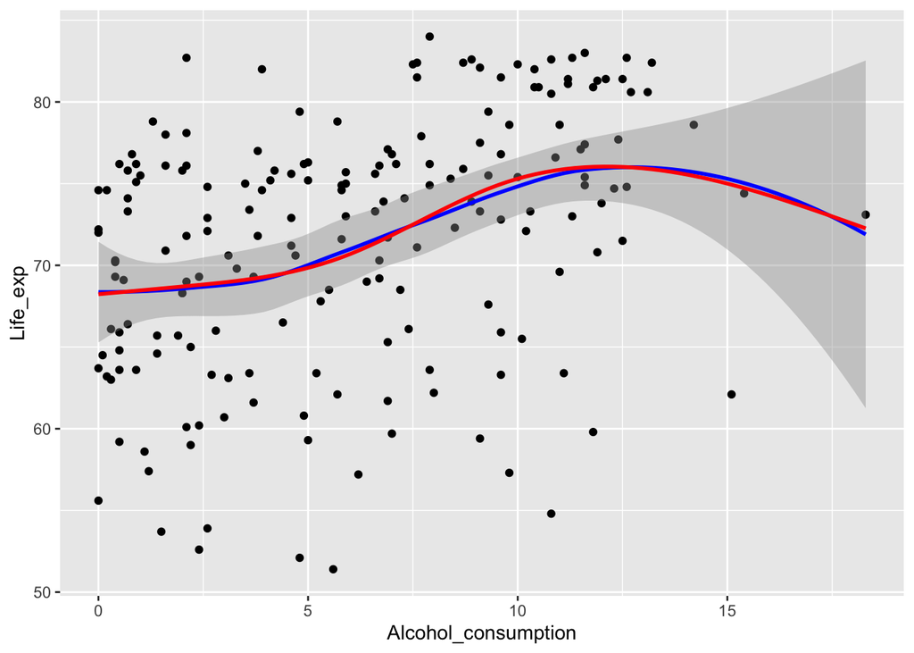

```r
ggplot(full_knn, aes(x=Alcohol_consumption, y=Life_exp))+
  geom_point()+
  geom_smooth(color="blue")+
  geom_smooth(formula = y~ns(x,4),method="lm",
      se= FALSE, color="red"
  )
```

Then we conduct the multivariate regression analysis:

```r
model_overall <- lm(Life_exp ~ ns(Happiness,4) + ns(National_income,5) + ns(lat,3) + ns(Govexp_health,5) +   Alcohol_consumption, data = full_knn)

summary(model_overall)
```

```
##
## Call:
## lm(formula = Life_exp ~ ns(Happiness, 4) + ns(National_income,
##     5) + ns(lat, 3) + ns(Govexp_health, 5) + Alcohol_consumption,
##     data = full_knn)
##
## Residuals:
##      Min       1Q   Median       3Q      Max
## -14.2016  -1.9291   0.3904   2.0839   8.9775
##
## Coefficients:
##                         Estimate Std. Error t value Pr(>|t|)
## (Intercept)             55.07354    3.17541  17.344  < 2e-16 ***
## ns(Happiness, 4)1        0.27479    2.51973   0.109 0.913288
## ns(Happiness, 4)2        2.98141    2.18130   1.367 0.173502
## ns(Happiness, 4)3        3.61050    5.58270   0.647 0.518685
## ns(Happiness, 4)4        4.12076    2.68510   1.535 0.126733
## ns(National_income, 5)1  5.53713    1.67194   3.312 0.001134 **
## ns(National_income, 5)2 10.91483    2.10690   5.181 6.24e-07 ***
## ns(National_income, 5)3  6.82547    2.59915   2.626 0.009432 **
## ns(National_income, 5)4 16.89059    3.90579   4.325 2.61e-05 ***
## ns(National_income, 5)5 11.06949    3.47916   3.182 0.001743 **
## ns(lat, 3)1              7.38186    1.35719   5.439 1.85e-07 ***
## ns(lat, 3)2              2.89048    3.78289   0.764 0.445878
## ns(lat, 3)3              1.74298    1.78592   0.976 0.330480
## ns(Govexp_health, 5)1    7.50232    1.55386   4.828 3.07e-06 ***
## ns(Govexp_health, 5)2    6.29747    1.78172   3.534 0.000527 ***
## ns(Govexp_health, 5)3   10.03449    2.47972   4.047 7.89e-05 ***
## ns(Govexp_health, 5)4   12.26800    3.37640   3.633 0.000371 ***
## ns(Govexp_health, 5)5    5.53057    3.07000   1.801 0.073409 .
## Alcohol_consumption     -0.08827    0.08855  -0.997 0.320293
## ---
## Signif. codes:  0 '***' 0.001 '**' 0.01 '*' 0.05 '.' 0.1 ' ' 1
##
## Residual standard error: 3.812 on 169 degrees of freedom
## Multiple R-squared:  0.773,  Adjusted R-squared:  0.7488
## F-statistic: 31.97 on 18 and 169 DF,  p-value: < 2.2e-16
```

```r
confint(model_overall)
```

```
##                              2.5 %      97.5 %
## (Intercept)             48.8049644 61.34211899
## ns(Happiness, 4)1       -4.6994138  5.24899123
## ns(Happiness, 4)2       -1.3246962  7.28751856
## ns(Happiness, 4)3       -7.4103196 14.63131332
## ns(Happiness, 4)4       -1.1798976  9.42142506
## ns(National_income, 5)1  2.2365420  8.83770903
## ns(National_income, 5)2  6.7555980 15.07405687
## ns(National_income, 5)3  1.6944815 11.95646217
## ns(National_income, 5)4  9.1801710 24.60101416
## ns(National_income, 5)5  4.2012713 17.93770870
## ns(lat, 3)1              4.7026371 10.06108416
## ns(lat, 3)2             -4.5773360 10.35829072
## ns(lat, 3)3             -1.7826009  5.26856837
## ns(Govexp_health, 5)1    4.4348358 10.56980423
## ns(Govexp_health, 5)2    2.7801848  9.81476094
## ns(Govexp_health, 5)3    5.1392706 14.92971470
## ns(Govexp_health, 5)4    5.6026549 18.93334658
## ns(Govexp_health, 5)5   -0.5299206 11.59106541
## Alcohol_consumption     -0.2630813  0.08654402
```

From the new regression model, we can see that the coefficient for `Alcohol Consumption` is -0.08827, which means that with one liter of pure alcohol consumed increased in the world per year, the life-expectancy is expected to be shortened by 0.08827 years on average, with all other variables held constant. However, the p-value for the coefficient is larger than 0.05, which means that the result is not statistically significant. The 95% confidence interval includes 0, which means that we can not know if `Alcohol Consumption` have causal effect on `Life_exp`.

**Sensitivity Analysis:**

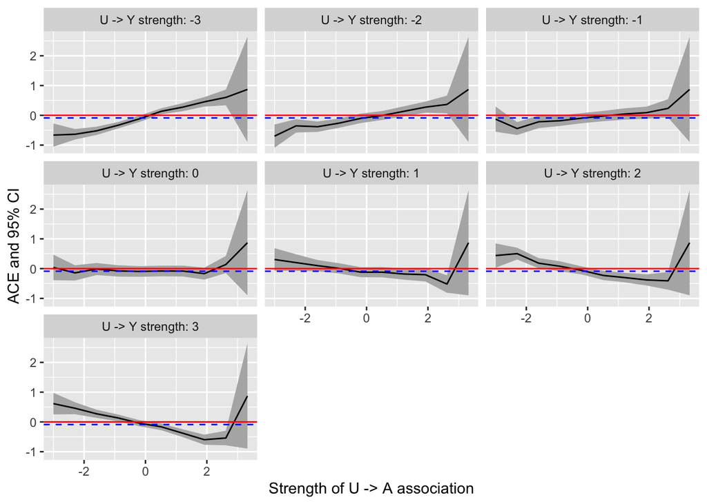

```r
sensitivity_analysis1 <- function(.data, model_A, model_Y, assoc_A, assoc_Y) {
    n <- nrow(.data)

    # Obtain residuals with residuals()
    # Obtain residual variances with sigma()
    res_A <- residuals(model_A)
    res_var_A <- sigma(model_A)^2
    res_Y <- residuals(model_Y)
    res_var_Y <- sigma(model_Y)^2

    # Compute the mean and variance of U given A and Y
    mean_U_term1 <- (assoc_A/res_var_A)*res_A
    mean_U_term2 <- (((res_var_A - assoc_A^2)*assoc_Y)/(res_var_A*res_var_Y))*res_Y
    mean_U <- mean_U_term1 + mean_U_term2

    var_U_term1 <- (res_var_A - assoc_A^2)/(res_var_A*res_var_Y)
    var_U_term2 <- res_var_Y - assoc_Y^2 + ((assoc_A*assoc_Y)^2)/res_var_A
    var_U <- var_U_term1*var_U_term2

    # Simulate U and add it to the data
    U <- rnorm(n, mean = mean_U, sd = sqrt(var_U))
    .data$U <- U

    ########################################################################
    # The part below is the only part you need to change to implement
    # the sensitivity analysis in a new context.

    # Refit model to estimate the causal effect
    updated_model <- lm(Life_exp ~ ns(Happiness,4) + ns(National_income,5) + ns(lat,3) + ns(Govexp_health,5) + Alcohol_consumption + U, data = full_knn)
    # The names of the coefficients and confidence interval output rows
    # are called "A" for the treatment variable A.
    # This will change in a new dataset.
    list(c(
        estimate = unname(coefficients(updated_model)["Alcohol_consumption"]),
        ci_95_lower = confint(updated_model)["Alcohol_consumption",1],
        ci_95_upper = confint(updated_model)["Alcohol_consumption",2]
    ))
}


# Begin the sensitivity analysis

# Fit required models for the sensitivity analysis
mod_A <- lm(Alcohol_consumption ~ ns(Happiness,5) + ns(National_income,5) + ns(lat,4) + ns(Govexp_health,4), data = full_knn)
mod_Y <- lm(Life_exp ~ ns(Happiness,4) + ns(National_income,5) + ns(lat,3) + ns(Govexp_health,5) + Alcohol_consumption, data = full_knn)

# Set up degree of association between U and A and between U and Y
# The U->A associations have some constraints: we set up values
# for the U->A associations that are at most equal to the
# standard deviation of the residuals from the model for A.
U_A_assocs <- seq(from = -3, to = sigma(mod_A), length.out = 10)
U_Y_assocs <- seq(from = -3, to = sigma(mod_Y), by = 1)

# Form all combinations of the U->A and U->Y sensitivity parameters
sens_data <- expand.grid(U_A = U_A_assocs, U_Y = U_Y_assocs)

# Run sensitivity analysis
sens_data <- sens_data %>%
    group_by(U_A, U_Y) %>%
    mutate(sens = sensitivity_analysis1(full_knn, mod_A, mod_Y, U_A, U_Y))
# Collect sensitivity analysis results in a data.frame
sens_data <- bind_cols(sens_data[,1:2], bind_rows(sens_data$sens))


# Plot results
prepender <- function(string, prefix = "U -> Y strength:") paste(prefix, string)

ggplot(sens_data, aes(x = U_A, y = estimate)) +
    geom_ribbon(aes(ymin = ci_95_lower, ymax = ci_95_upper), fill = "grey70") +
    geom_line() +
    geom_hline(aes(yintercept = coefficients(mod_Y)["Alcohol_consumption"]), color = "blue", lty = "dashed") +
    geom_hline(aes(yintercept = 0), color = "red") +
    facet_wrap(~U_Y, labeller = as_labeller(prepender)) +
    labs(x = "Strength of U -> A association", y = "ACE and 95% CI")
```

The analysis above shows that if there exists an unobserved variable in the model, its correlation with Y should remain close to 0 and its correlation with A should remain in smaller range, ideally in (-2,2), for the sake of having a causal effect that is consistent with the causal effect shown by the coefficient in the model.

### 4. IPW analysis

Compared to regression analysis that basically blocks all non-causal paths by conditioning on confounders, IPW (inverse probability weighting) analysis basically removes the arrow between potential confounders and treatment by re-weighting every row of data, so that the original confounders should no more affecting the result.

To calculate the corrected weight, we first looked at the relationship between confounders and treatment (Alcohol Consumption):

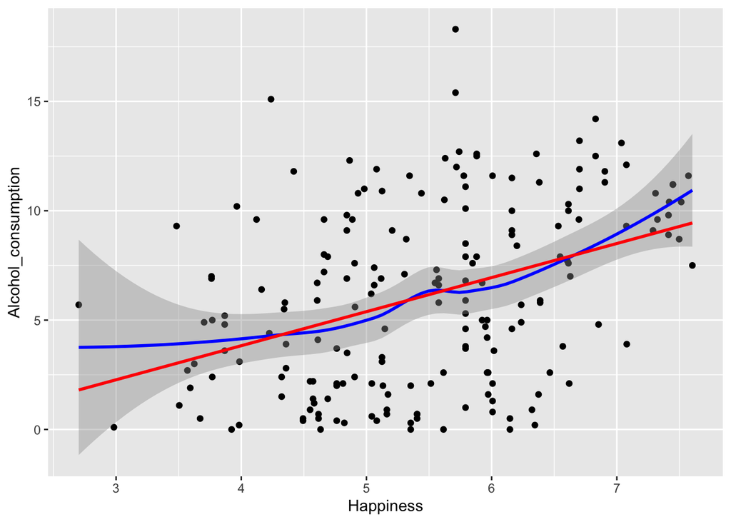

```r
ggplot(full_knn, aes(x=Happiness, y=Alcohol_consumption))+
  geom_point()+
  geom_smooth(color="blue")+
  geom_smooth(formula = y~x,method="lm",
      se= FALSE, color="red"
  )
```

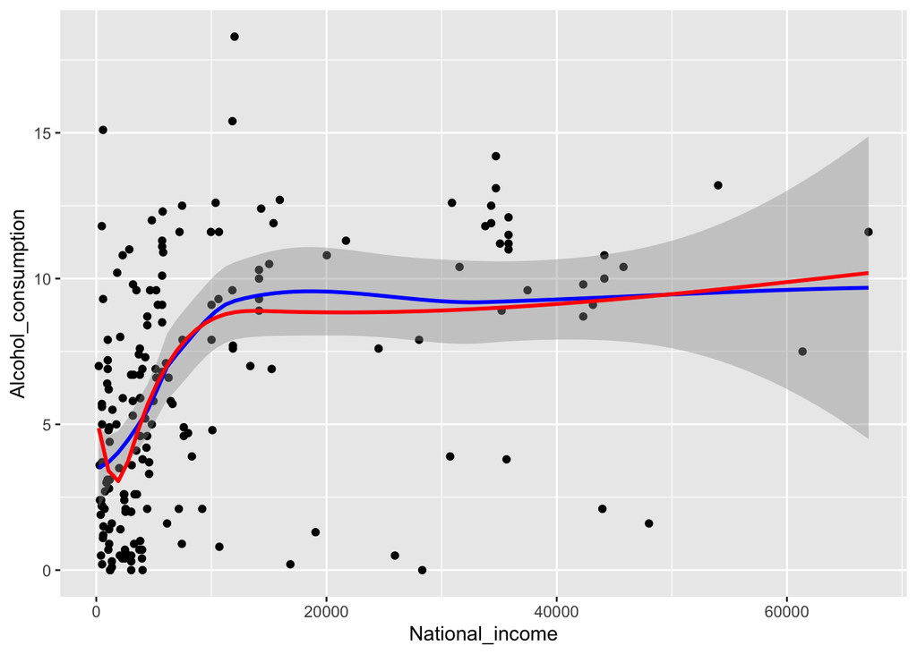

```r
ggplot(full_knn, aes(x = National_income, y=Alcohol_consumption))+
  geom_point()+
  geom_smooth(color="blue")+
  geom_smooth(formula = y~ns(x,5),method="lm",
      se= FALSE, color="red"
  )
```

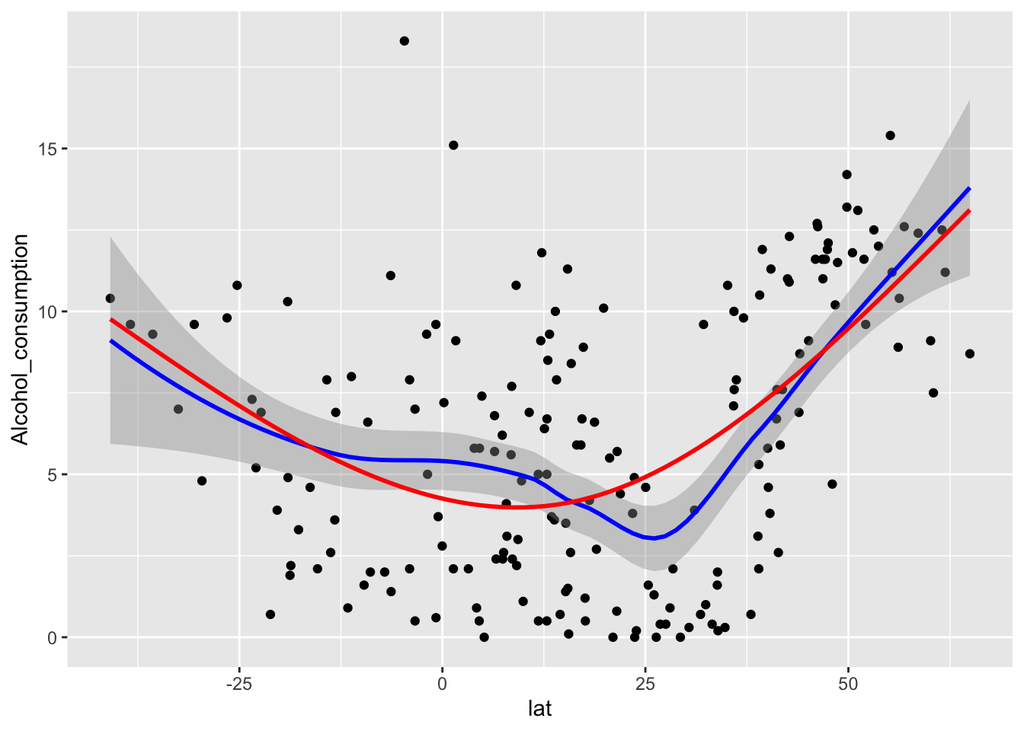

```r
ggplot(full_knn, aes(x=lat, y=Alcohol_consumption))+
  geom_point()+
  geom_smooth(color="blue")+
  geom_smooth(formula = y~ns(x,2),method="lm",
      se= FALSE, color="red"
  )
```

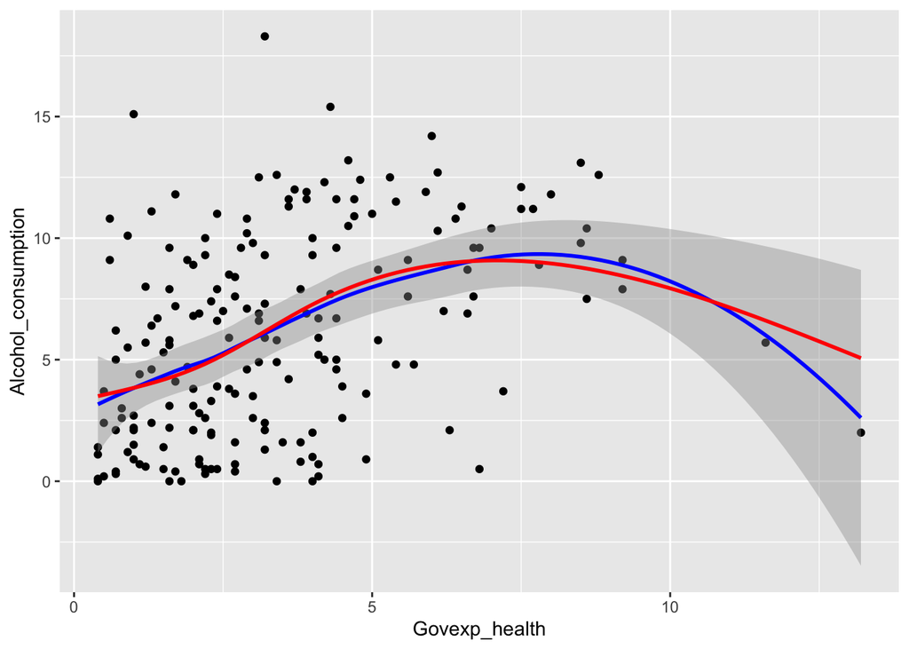

```r
ggplot(full_knn, aes(x=Govexp_health, y=Alcohol_consumption))+
  geom_point()+
  geom_smooth(color="blue")+
  geom_smooth(formula = y~ns(x,3),method="lm",
      se= FALSE, color="red"
  )
```

Based on our visualizations above, we investigated the general relationship between confounders and treatment, and based on that calculated the inverse-probability weighting that would remove the relation:

```r
set.seed(451)
# estimation of denominator of ip weights
den.fit.obj <- lm(
  Alcohol_consumption ~ Happiness + ns(National_income,5) + ns(lat,2) + ns(Govexp_health,3), data = full_knn
)
p.den <- predict(den.fit.obj, type = "response")
dens.den <-
  dnorm(full_knn$Alcohol_consumption,
        p.den,
        summary(den.fit.obj)$sigma)

# estimation of numerator of ip weights
num.fit.obj <- lm(Alcohol_consumption ~ 1, data = full_knn)
p.num <- predict(num.fit.obj, type = "response")
dens.num <-
  dnorm(full_knn$Alcohol_consumption,
        p.num,
        summary(num.fit.obj)$sigma)

full_knn$ipw <- dens.num / dens.den
summary(full_knn$ipw)
```

```
##    Min. 1st Qu.  Median    Mean 3rd Qu.    Max.
##  0.1223  0.5373  0.7684  1.0506  0.9896 23.5300
```

With the weight added, life expectancy and alcohol consumption can be directly compared:

```r
library(survey)
design <- svydesign(ids = ~0, weights = full_knn$ipw, data = full_knn)

msm_fit <- svyglm(
    Life_exp ~ Alcohol_consumption,
    data = data,
    design = design
)
summary(msm_fit)
```

```
##
## Call:
## svyglm(formula = Life_exp ~ Alcohol_consumption, design = design,
##     data = data)
##
## Survey design:
## svydesign(ids = ~0, weights = full_knn$ipw, data = full_knn)
##
## Coefficients:
##                     Estimate Std. Error t value Pr(>|t|)
## (Intercept)          72.4504     1.0786  67.168   <2e-16 ***
## Alcohol_consumption  -0.4342     0.2124  -2.044   0.0423 *
## ---
## Signif. codes:  0 '***' 0.001 '**' 0.01 '*' 0.05 '.' 0.1 ' ' 1
##
## (Dispersion parameter for gaussian family taken to be 60.16991)
##
## Number of Fisher Scoring iterations: 2
```

```r
confint(msm_fit)
```

```
##                          2.5 %      97.5 %
## (Intercept)         70.3362696 74.56447730
## Alcohol_consumption -0.8504614 -0.01788759
```

In the marginal structural model, the coefficient for `Alcohol_consumption` is -0.4342, which means that the if someone increases alcohol consumption by 1 litre per year, his/her life expectancy is likely to decrease by 0.4342 year. Here, the p-value is 0.0423, which was slightly smaller than 0.05, and the 95% CI for the coefficient of `Alcohol_consumption` is (-0.8504614, -0.01788759), which does not includes 0, indicating that the association would be statistically significant enough. However, both the p-value and the CI are not that far away from alpha or 0, so I think it is still plausible that the result is practically insignificant.

**Sensitivity Analysis:**

Here, we tried another imputation algorithm `hotdeck` to conduct another kind of sensitivity analysis to see if our ipw analysis result would change a lot and hence to see if the analysis was robust enough. Similar to KNN, hotdeck imputes NAs also by looking for the data in a "close" unit. The difference is that KNN looks at many units close to the one with missing value and weigh the units to get an average, but hotdeck looks for a unit that is closeset to the one with missing value and use the value of that unit to impute the NA.

```r
set.seed(451)
full_hotdeck  <-  full %>%
  VIM::hotdeck(imp_var = FALSE)
```

```r
# estimation of denominator of ip weights
den.fit.obj <- lm(
  Alcohol_consumption ~ Happiness + ns(National_income,5) + ns(lat,2) + ns(Govexp_health,3), data = full_hotdeck
)
p.den <- predict(den.fit.obj, type = "response")
dens.den <-
  dnorm(full_hotdeck$Alcohol_consumption,
        p.den,
        summary(den.fit.obj)$sigma)

# estimation of numerator of ip weights
num.fit.obj <- lm(Alcohol_consumption ~ 1, data = full_hotdeck)
p.num <- predict(num.fit.obj, type = "response")
dens.num <-
  dnorm(full_hotdeck$Alcohol_consumption,
        p.num,
        summary(num.fit.obj)$sigma)

full_hotdeck$ipw <- dens.num / dens.den
summary(full_hotdeck$ipw)
```

```
##    Min. 1st Qu.  Median    Mean 3rd Qu.    Max.
##  0.1231  0.6093  0.8169  1.0234  1.0205 17.0775
```

```r
library(survey)
design <- svydesign(ids = ~0, weights = full_hotdeck$ipw, data = full_hotdeck)

msm_fit <- svyglm(
    Life_exp ~ Alcohol_consumption,
    data = data,
    design = design
)
summary(msm_fit)
```

```
##
## Call:
## svyglm(formula = Life_exp ~ Alcohol_consumption, design = design,
##     data = data)
##
## Survey design:
## svydesign(ids = ~0, weights = full_hotdeck$ipw, data = full_hotdeck)
##
## Coefficients:
##                     Estimate Std. Error t value Pr(>|t|)
## (Intercept)          71.0170     1.2407  57.239   <2e-16 ***
## Alcohol_consumption  -0.1762     0.2389  -0.737    0.462
## ---
## Signif. codes:  0 '***' 0.001 '**' 0.01 '*' 0.05 '.' 0.1 ' ' 1
##
## (Dispersion parameter for gaussian family taken to be 59.57208)
##
## Number of Fisher Scoring iterations: 2
```

```r
confint(msm_fit)
```

```
##                          2.5 %     97.5 %
## (Intercept)         68.5852963 73.4487631
## Alcohol_consumption -0.6445369  0.2921237
```

Under the imputation from hotdeck algorithm, the coefficient for `Alcohol_consumption` is -0.1762, which means that the if someone increases alcohol consumption by 1 litre per year, his/her life expectancy is likely to decrease by 0.1762 year. Here, the p-value is 0.462, which was greater than 0.05, and the 95% CI for the coefficient of `Alcohol_consumption` is (-0.6445369, 0.2921237), which also includes 0, indicating that the association would not be statistically significant enough.

### 5. Causal Discovery

Causal discovery could be used as a sensitivity analysis for a regression or IP weighting analysis for estimating causal effects. When we do regression or IP weighting analysis, there could be confounders that we neglected and these neglected confunders could make our conclusion invalid. For example, if we found equivalence classes of causal structures for three variables, then we know that there are three possible possible scenarios. If in our regression, we only analyzed one potential scenario, then we should do alternate analyses of our data. Causal discovery can also helps to check if our regression or IP weighting analysis is correct. For example, if causal discovery indicates one variable to be a collision node but our regression indicates the opposite, then we should be careful and rexamine the causal relationship. To learn the structure of causal graphs from data, we need first make an assumption that if we obverse conditional independence in the data, we naturally expect the corresponding d-separation. That is, we assume the joint distribution of the data is faithful to the DAG. Then we are going to use PC algorithm to show the causal relationship between variables from data.

```r
variables <- full_knn %>%
  select(Alcohol_consumption,lat, Life_exp, Happiness, National_income, Literacy_rate, Govexp_health )
```

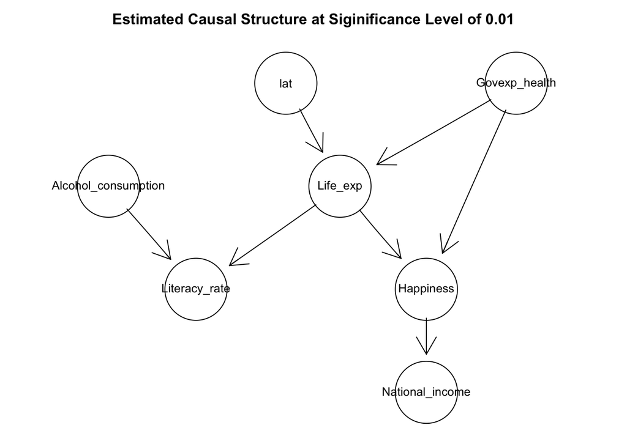

```r
suff_stat <- list(C = cor(variables), n = nrow(variables))
pc_variables <- pc(suff_stat, indepTest = gaussCItest, labels = colnames(variables), alpha = 0.01, skel.method = "stable.fast")
par(cex=0.5)
plot(pc_variables, main = "Estimated Causal Structure at Siginificance Level of 0.01", sub="", cex.main=2)
```

At significance level for the individual conditional independence tests of 0.01, from the causal structure above, we can see that `lat` and `Government expnditure on health` will cause change in our outcome `Life expectancy`. `Life expectancy` and `Alcohol consumption` will lead changes in `Literacy rate`. Also, `Life expectancy` and `Govexp_health` will cause `Happiness` to change. Finally, `Happiness` then cause changes in `National income`. In this causal structure, the known noncausal path is: `Alcohol consumption` -> `Literacy rate` <- `Life expectancy`. Since `Literacy rate` is a collision node, we should not condition on it to achieve conditional exchangeability.  
This estimated causal graph from data is significantly different from our hypothesized causal graph. However, it doesn't mean that our initial hypothesized causal relationships are wrong, but this estimated causal graph from data suggested another possibility of what the causal relationships among these variables could be.

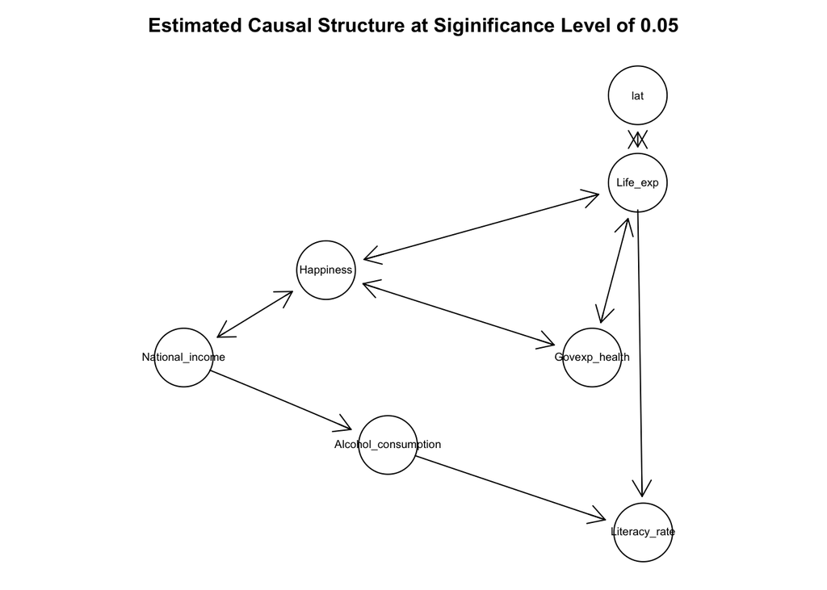

```r
suff_stat <- list(C = cor(variables), n = nrow(variables))
pc_variables <- pc(suff_stat, indepTest = gaussCItest, labels = colnames(variables), alpha = 0.05, skel.method = "stable.fast")

par(cex=0.5)
plot(pc_variables, main = "Estimated Causal Structure at Siginificance Level of 0.05", sub="", cex.main=2)
```

At significance level for the individual conditional independence tests of 0.05, from the causal structure above, we can see that from data, we know`lat`, `Government expnditure on health` and `Hapniness` are associated with our outcome `Life expectancy`, but the causal relationship is undetermined. Also, `Hapniness` and `National income` are assoctiated but we don't know which variable will cause the other to change. `National income` will lead to change in `Alcohol consumption`. `Alcohol consumption` and `Life expectancy` will cause change in `Literacy rate`. In this causal structure, the known noncausal path is: `Alcohol consumption` -> `Literacy rate` <- `Life expectancy`. Since `Literacy rate` is a collision node, we should not condition on it to achieve conditional exchangeability.  
This estimated causal graph from data is significantly different from our hypothesized causal graph. It is also different from the causal structure we estimated with significance level of 0.01. Again, it doesn't mean that our initial hypothesized causal relationships are wrong, but this estimated causal graph from data suggested another possibility of what the causal relationships among these variables could be.  
Both the causal structure with significance level of 0.01 and 0.05 suggest we should not condition on `Literacy rate` to acheive conditional exchangeability. This suggests that it is correct to exclude `Literacy rate` in our previous conditioning set Z = {`Happiness`, `National_income`, `lat`, `Govexp_health`}.

### 7. limitations

Though in the regression part and IPW part the results show the same conclusion for the causal effect between drinking and life expectancy, such a result might be misleading since we have used imputation methods for missing values(NAs) in our dataset. This could lead to overestmating or underestimating the causal effect between drinking and life expectancy since the existing data might show biased trend for imputation and thus lead to misleading imputation results and therefore overfit the models. Such concerns deserves further attention in future studies.

### 8. Conclusion

In conclusion, our regression analysis and ipw analyis both showed that alcohol consumption is likely to shorten life expectancy, but based on p-value and sensitivity analysis, the result cannot be said as quite significant or robust. However, since both analyses results showed a negative relationship between alcohol consumption and life expectancy (though there exists some limitations and the conditioning set might not be accurate enough), this is still a social problem that worth paying attention to. We really hope that this question can be further investigated in the future and somewhat contribute to extending people's life.